# Rising Economies of Leisure Airports Post-COVID

Riya Saini

As someone new to Aviation and airport planning, I want to understand how large tourist airport systems operate. I’m particularly interested in tourist airports that are a hub for LCC and ULLC airlines such as Southwest, JetBlue, Allegiant Air and Spirit. These airlines typically hub at major tourist airports due to the high demand along leisure-focused routes. For my analysis, I have selected the years 2019, 2021, and 2023 to examine the shifts in operations and business strategies of tourist-centric airports before and after the COVID-19 pandemic. The airports chosen for this study are:

- Orlando International Airport (MCO), Florida
- Fort Lauderdale-Hollywood International Airport (FLL), Florida
- Harry Reid International Airport (LAS), Nevada

These airports are among the largest tourism hubs in the United States, with a strong reliance on leisure passengers. While other airports like ATL, JFK, and LAX also serve a significant number of tourists, they are also major business and international hubs. In contrast, MCO, FLL, and LAS are more specialized in serving tourists, such as those traveling to Orlando for Disneyland, Fort Lauderdale for its beaches, and Las Vegas for its casinos.

Additionally, these airports are more vulnerable to disruptions caused by environmental factors, such as the COVID-19 pandemic. This analysis will focus on how these airports navigated the pandemic, the recovery of tourism, and how their revenue structures have shifted in the wake of changing travel patterns.

```r
dat_2019 <- read.csv(file = "Report127_2019.csv")
dat_2021 <- read.csv(file = "Report127_2021.csv")
dat_2023 <- read.csv(file = "Report127_2023.csv")

selected_airports <- c("MCO", "FLL", "LAS")

airports_2019 <- dat_2019 %>%
  filter(LOC_ID %in% selected_airports)
airports_2021 <- dat_2021 %>%
  filter(LOC_ID %in% selected_airports)
airports_2023 <- dat_2023 %>%
  filter(LOC_ID %in% selected_airports)

airports <- bind_rows(
  airports_2019 %>% mutate(year = 2019),
  airports_2021 %>% mutate(year = 2021),
  airports_2023 %>% mutate(year = 2023))

columns_to_plot <- c("Total.Passenger.Airline.Aeronautical.Revenue","Total.Non.Passenger.Aeronautical.Revenue","Total.Aeronautical.Revenue",
                     "Total.Non.Aeronautical.Revenue", "Total.Operating.Revenue","Total.Operating.Expenses","Total.Non.Operating.Revenue",
                     "Enplanements","Annual.aircraft.operations", "Passenger.airline.cost.per.enplanement")

airports_long <- airports %>%
  select(all_of(columns_to_plot), LOC_ID, year) %>%
  pivot_longer(cols = -c(LOC_ID, year), names_to = "variable", values_to = "value")

# color scheme
airport_colors <- c("MCO" = "#A3C1DA", "FLL" = "#D1A3D2", "LAS" = "#B2E7A1")
```

## Revenue Breakdown

#### Total Passenger Airline Aeronautical Revenue and Total Non-Passenger Aeronautical Revenue

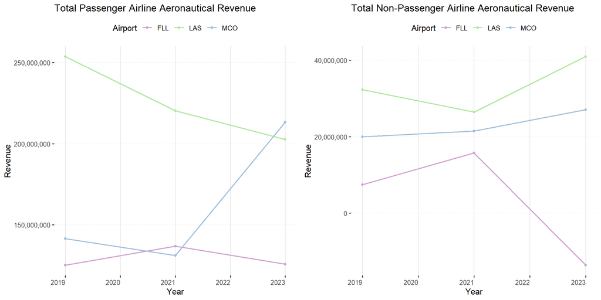

```r
p1 <- ggplot(airports_long %>% filter(variable == "Total.Passenger.Airline.Aeronautical.Revenue" & LOC_ID %in% selected_airports),
       aes(x = year, y = value, color = LOC_ID)) +
  geom_line(size = 0.8) +
  geom_point() +
  scale_color_manual(values = airport_colors) +
  scale_y_continuous(labels = label_comma()) +
  theme_pubclean() +
  theme(
    axis.text.x = element_text(hjust = 1),
    panel.grid.major = element_line(size = 0.1, color = "gray80"),
    panel.grid.minor = element_blank()) +
  labs(title = "Total Passenger Airline Aeronautical Revenue",
       x = "Year",
       y = "Revenue", color = "Airport")

p2 <- ggplot(airports_long %>% filter(variable == "Total.Non.Passenger.Aeronautical.Revenue" & LOC_ID %in% selected_airports),
       aes(x = year, y = value, color = LOC_ID)) +
  geom_line(size = 0.8) +
  geom_point() +
  scale_color_manual(values = airport_colors) +
  scale_y_continuous(labels = label_comma()) +
  theme_pubclean() +
  theme(
    axis.text.x = element_text(hjust = 1),
    panel.grid.major = element_line(size = 0.1, color = "gray80"),
    panel.grid.minor = element_blank()) +
  labs(title = "Total Non-Passenger Airline Aeronautical Revenue",
       x = "Year",
       y = "Revenue", color = "Airport")

grid.arrange(p1, p2, ncol = 2)
```

Total Passenger Airline Aeronautical Revenue refers to the revenue that an airport earns from airline-related operations directly associated with passenger air travel. This includes various fees such as “Passenger airline landing fees”, “Terminal arrival fees…rents…utilities”, “Terminal area apron charges tiedowns”, “Federal Inspection Fees”, and “Other passenger aeronautical fees”. These charges are paid by airlines for the use of the airport’s facilities and services, such as runways, terminals, baggage handling, and passenger boarding gates.

An interesting trend emerges when analyzing this revenue stream: while the revenue earned at FLL returned to pre-pandemic levels after a peak in 2021, MCO saw a significant increase in revenue. On the other hand, LAS experienced a decline in passenger airline aeronautical revenue despite a rise in enplanements.

Total Non-Passenger Aeronautical Revenue includes earnings from aviation-related activities that do not directly involve passenger airlines. This encompasses sources such as “Landing fees from cargo”, “Landing fees from GA and military”, “FBO revenue…contract or sponsor operated”, “Cargo and hangar rentals”, “Fuel sales net profit loss or fuel flowage fees”, and “Other non passenger aeronautical revenue”. For airports serving as major tourist destinations, non-passenger aeronautical revenue tends to be smaller in comparison, as the focus is primarily on passenger flights. However, these revenue streams still provide important diversification, particularly when passenger traffic fluctuates.

#### Total Aeronautical Revenue

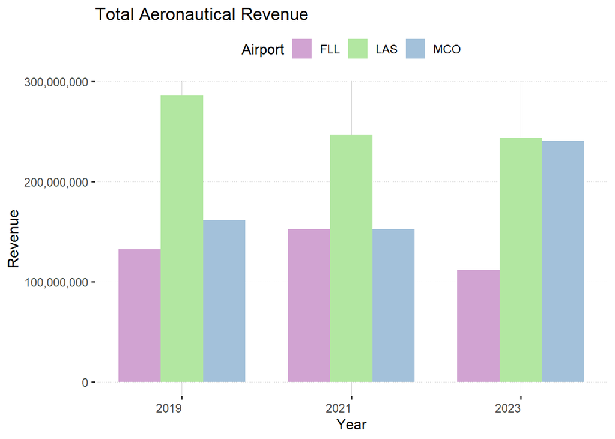

```r
ggplot(airports_long %>% filter(variable == "Total.Aeronautical.Revenue" & LOC_ID %in% selected_airports),
       aes(x = year, y = value, fill = LOC_ID)) +
  geom_bar(stat = "identity", position = "dodge", width = 1.5) +
  scale_fill_manual(values = airport_colors) +
  scale_y_continuous(labels = label_comma()) +
  scale_x_continuous(breaks = c(2019, 2021, 2023)) +
  theme_pubclean() +
  theme(
    axis.text.x = element_text(hjust = 1),
    panel.grid.major = element_line(size = 0.1, color = "gray80"),
    panel.grid.minor = element_blank()
  ) +
  labs(title = "Total Aeronautical Revenue",
       x = "Year",
       y = "Revenue", fill = "Airport")
```

#### Total Non-Aeronautical Revenue

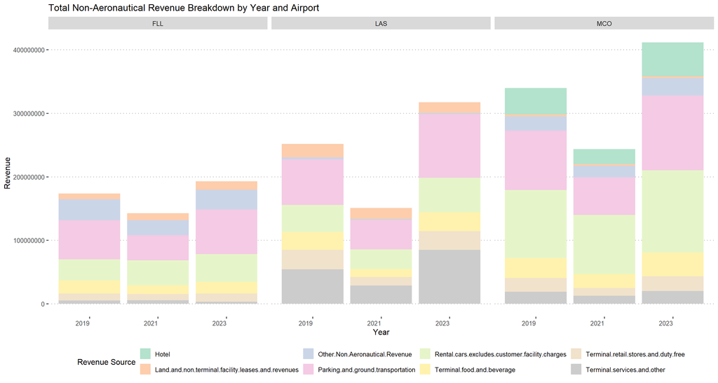

```r
# Select relevant revenue columns and pivot to long format
non_aero_revenue_long <- airports %>%
  select(LOC_ID, year, Land.and.non.terminal.facility.leases.and.revenues,
         Terminal.food.and.beverage, Terminal.retail.stores.and.duty.free,
         Terminal.services.and.other, Rental.cars.excludes.customer.facility.charges,
         Parking.and.ground.transportation, Hotel, Other.Non.Aeronautical.Revenue) %>%
  pivot_longer(cols = -c(LOC_ID, year), names_to = "Revenue_Source", values_to = "Revenue")

# Create stacked bar chart
ggplot(non_aero_revenue_long, aes(x = factor(year), y = Revenue, fill = Revenue_Source)) +
  geom_bar(stat = "identity", position = "stack") +
  facet_wrap(~LOC_ID, scales = "fixed") +
  scale_fill_brewer(palette = "Pastel2") +
  theme_pubclean() +
  labs(title = "Total Non-Aeronautical Revenue Breakdown by Year and Airport",
       x = "Year",
       y = "Revenue",
       fill = "Revenue Source") +
  theme(axis.text.x = element_text(hjust = 1),
    legend.position = "bottom")
```

For tourist-based airports, non-aeronautical revenue is also crucial. This category includes sources such as Land and non-terminal facility leases and revenues, Terminal food and beverage, Terminal retail stores and duty free, Terminal services and other, Rental cars excludes customer facility charges, Parking and ground transportation, Hotel, and Other non-aeronautical revenue. Non-aeronautical revenue provides a critical opportunity for airports to diversify their income and stabilize financially, especially during periods of decreased air travel. Additionally, it contributes to enhancing the passenger experience, turning airports into hubs of services rather than merely transit points. From the stacked bar chart showing the distribution of these services, MCO leads the other two airports in non-aeronautical revenue, particularly in on-site hotel and rental car operations. It outpaces FLL and LAS in these areas, underscoring the importance of its tourism-driven business model.

#### Total Operating Revenue

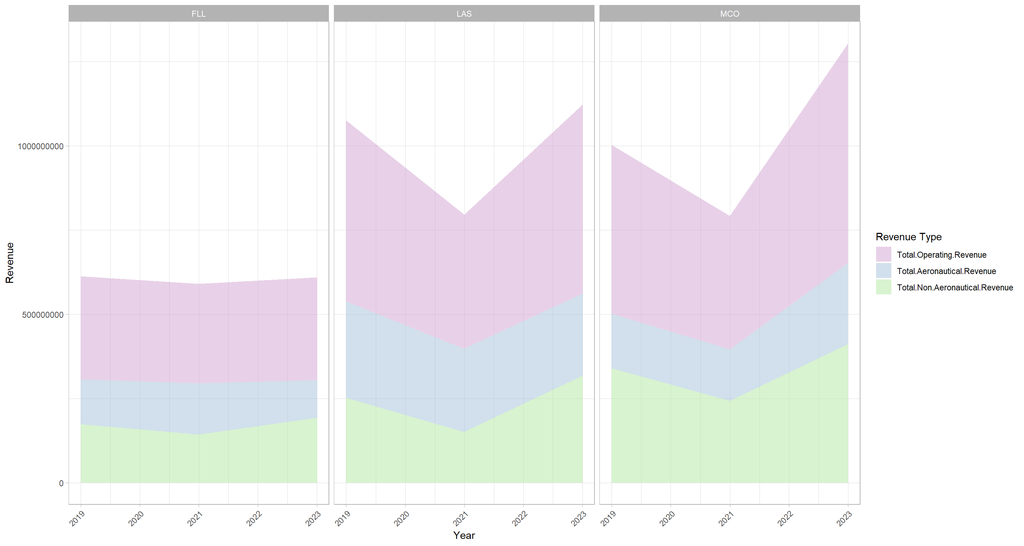

```r
# Define columns to plot
columns_to_plot2 <- c("Total.Aeronautical.Revenue",
                     "Total.Non.Aeronautical.Revenue",
                     "Total.Operating.Revenue")

# Reshape data
airports_long2 <- airports %>%
  select(all_of(columns_to_plot2), LOC_ID, year) %>%
  pivot_longer(cols = -c(LOC_ID, year), names_to = "variable", values_to = "value") %>%
  mutate(variable = factor(variable, levels = c("Total.Operating.Revenue",
                                                "Total.Aeronautical.Revenue",
                                                "Total.Non.Aeronautical.Revenue")))

airport_colors2 <- c(
  "Total.Aeronautical.Revenue" = "#A3C1DA",
  "Total.Non.Aeronautical.Revenue" = "#B2E7A1",
  "Total.Operating.Revenue" = "#D1A3D2")

# Create a stacked area chartr
ggplot(airports_long2, aes(x = year, y = value, fill = variable)) +
  geom_area(position = "stack", alpha = 0.5) +
  scale_fill_manual(values = airport_colors2) +
  facet_wrap(~LOC_ID) +
  theme_light() +
  labs(x = "Year", y = "Revenue", fill = "Revenue Type") +
  theme(axis.text.x = element_text(angle = 45, hjust = 1))
```

Total operating revenue for an airport is the combination of both **total aeronautical revenue** and **total non-aeronautical revenue**. For FLL, although it experienced a drop in aeronautical revenue, it made up for the loss through non-aeronautical services, resulting in net operating revenue that remained steady year-over-year. MCO, benefiting from its strong non-aeronautical revenue streams, surpassed LAS in total operating revenue.

#### Total Non-Operating Revenue

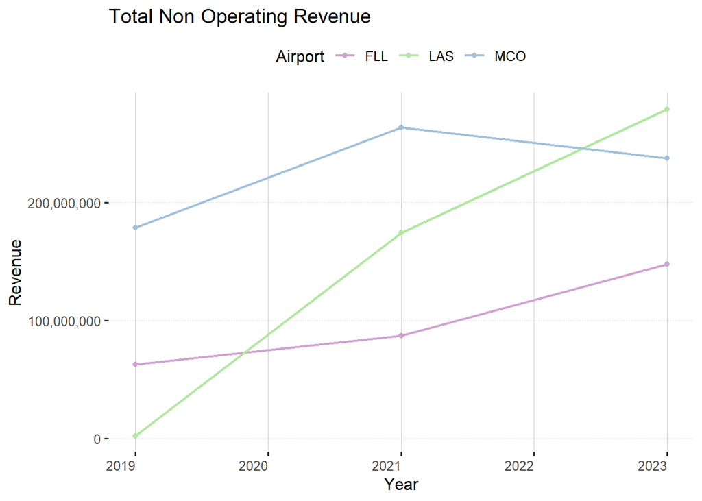

```r
ggplot(airports_long %>% filter(variable == "Total.Non.Operating.Revenue" & LOC_ID %in% selected_airports),
       aes(x = year, y = value, color = LOC_ID)) +
  geom_line(size = 0.8) +
  geom_point() +
  scale_color_manual(values = airport_colors) +
  scale_y_continuous(labels = label_comma()) +
  theme_pubclean() +
  theme(
    axis.text.x = element_text(hjust = 1),
    panel.grid.major = element_line(size = 0.1, color = "gray80"),
    panel.grid.minor = element_blank()) +
  labs(title = "Total Non Operating Revenue",
       x = "Year",
       y = "Revenue", color = "Airport")
```

Total non-operating revenue consists of income from sources unrelated to an airport’s core aviation and passenger services. Unlike operating revenue, which stems from airlines, passengers, and commercial activities within the airport, non-operating revenue comes from external sources such as **Interest Income**, **Grants & Government**, **Passenger Facility Charges (PFCs)**, **Capital Contributions**, and **Special Items (Loss/Gains, Other Non-Operating)**. These sources, often provided by government or external financial activities, offer airports additional financial support.

In the case of LAS and FLL, both airports have seen an uptick in non-operating revenue since the pandemic, likely as part of efforts to boost tourism attraction and support airport operations. In contrast, MCO, which gained immense popularity due to its position as a family tourism destination, has actually seen a decline in non-operating revenue since 2021.

## Cost Breakdown

#### Total Operating Expenses

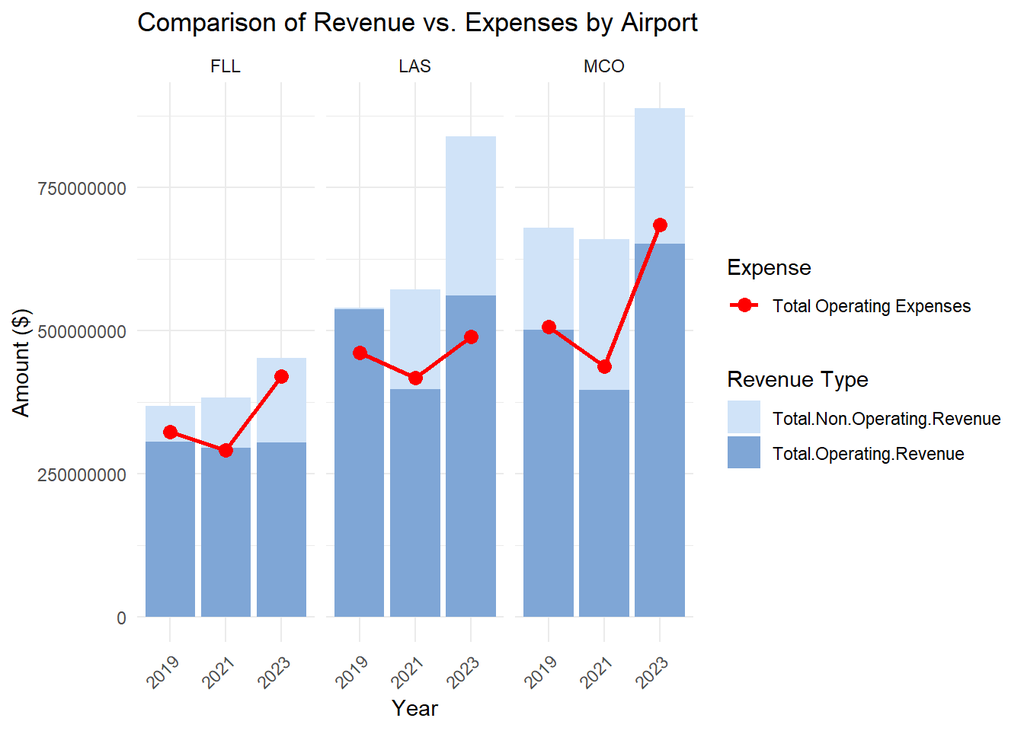

```r
# Reshape data for plotting
airports_long3 <- airports %>%
  select(LOC_ID, year, Total.Operating.Revenue, Total.Non.Operating.Revenue, Total.Operating.Expenses) %>%
  pivot_longer(cols = c(Total.Operating.Revenue, Total.Non.Operating.Revenue),
               names_to = "Revenue_Type", values_to = "Revenue_Value")

# Plot
ggplot() +
  geom_bar(data = airports_long3, aes(x = factor(year), y = Revenue_Value, fill = Revenue_Type),
           stat = "identity", position = "stack") +
  geom_point(data = airports, aes(x = factor(year), y = Total.Operating.Expenses, color = "Total Operating Expenses"), size = 3) +
  geom_line(data = airports, aes(x = factor(year), y = Total.Operating.Expenses, group = LOC_ID, color = "Total Operating Expenses"), size = 1) +
  facet_wrap(~LOC_ID) +
  theme_minimal() +
  labs(title = "Comparison of Revenue vs. Expenses by Airport",
       x = "Year", y = "Amount ($)",
       fill = "Revenue Type", color = "Expense") +
  scale_fill_manual(values = c("Total.Operating.Revenue" = "#7FA6D6", "Total.Non.Operating.Revenue" = "#D0E3F8")) +
  scale_color_manual(values = c("Total Operating Expenses" = "red")) +
  theme(axis.text.x = element_text(angle = 45, hjust = 1))
```

An airport generates substantial revenue through its on-ground facilities and airline operations. However, to determine if it can make a profit and invest in other air service incentives, it’s essential to consider its operating expenses. Total operating expenses include **Personnel compensation and benefits**, **Communications and utilities**, **Supplies and materials**, **Contractual services**, **Insurance claims and settlements**, and **Other operating expenses**, minus **Depreciation**.

As expected, MCO has the highest operating expenses given its extensive infrastructure and services. Comparing operating and non-operating revenue against operating expenses provides a clearer financial picture. While LAS and MCO report similar total revenue, MCO’s higher operating expenses stand out. In 2023, FLL spends almost all of its revenue on operating expenses, highlighting the financial pressure airports can face, especially those dependent on tourism-driven operations.

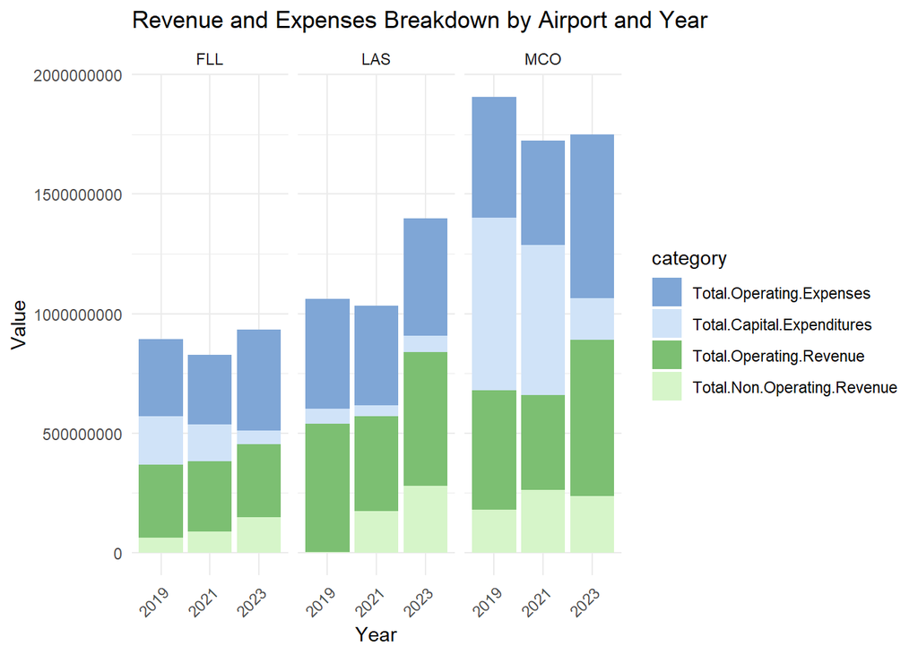

```r
# Convert data to a long format
airports_long4 <- airports%>%
  select(LOC_ID, year, Total.Operating.Revenue, Total.Non.Operating.Revenue,
         Total.Operating.Expenses, Total.Capital.Expenditures) %>%
  pivot_longer(cols = c(Total.Operating.Revenue, Total.Non.Operating.Revenue,
                        Total.Operating.Expenses, Total.Capital.Expenditures),
               names_to = "category", values_to = "value")

revenue_colors <- c("Total.Operating.Revenue" = "#7CBF72",
                    "Total.Non.Operating.Revenue" = "#D6F5C9")
expense_colors <- c("Total.Operating.Expenses" = "#7FA6D6",
                    "Total.Capital.Expenditures" = "#D0E3F8")

# Reorder
airports_long4$category <- factor(airports_long4$category,
                                 levels = c("Total.Operating.Expenses",
                                            "Total.Capital.Expenditures",
                                            "Total.Operating.Revenue",
                                            "Total.Non.Operating.Revenue"))

# Create the stacked bar chart
ggplot(airports_long4, aes(x = factor(year), y = value, fill = category)) +
  geom_bar(stat = "identity") +
  facet_wrap(~LOC_ID) +
  scale_fill_manual(values = c(expense_colors, revenue_colors)) +
  labs(title = "Revenue and Expenses Breakdown by Airport and Year",
       x = "Year", y = "Value") +
  theme_minimal() +
  theme(axis.text.x = element_text(angle = 45, hjust = 1))
```

## Operating Statistics

Understanding an airport’s financial health and operational efficiency requires a deeper look at key metrics such as **Annual Aircraft Operations**, **Enplanements**, and **Passenger Airline Cost per Enplanement**. These metrics provide insight into an airport’s capacity, passenger traffic, and cost efficiency in managing its operations.

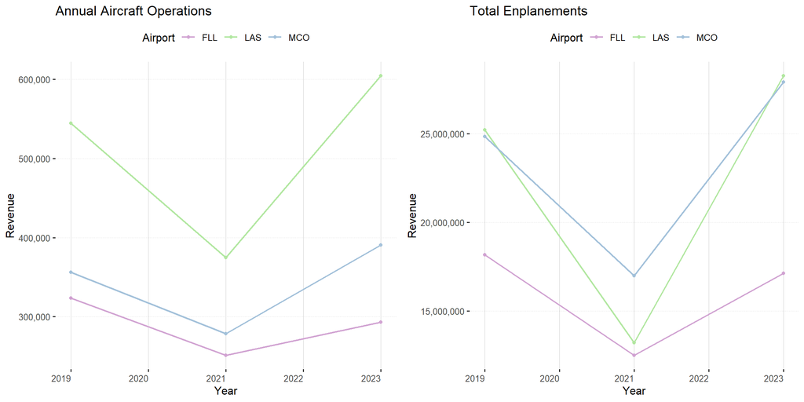

```r
# First plot for Annual Aircraft Operations
plot_1 <- ggplot(airports_long %>% filter(variable == "Annual.aircraft.operations" & LOC_ID %in% selected_airports),
       aes(x = year, y = value, color = LOC_ID)) +
  geom_line(size = 0.8) +
  geom_point() +
  scale_color_manual(values = airport_colors) +
  scale_y_continuous(labels = label_comma()) +
  theme_pubclean() +
  theme(
    axis.text.x = element_text(hjust = 1),
    panel.grid.major = element_line(size = 0.1, color = "gray80"),
    panel.grid.minor = element_blank()) +
  labs(title = "Annual Aircraft Operations",
       x = "Year",
       y = "Revenue", color = "Airport")


# Second plot for Enplanements
plot_2 <- ggplot(airports_long %>% filter(variable == "Enplanements" & LOC_ID %in% selected_airports),
       aes(x = year, y = value, color = LOC_ID)) +
  geom_line(size = 0.8) +
  geom_point() +
  scale_color_manual(values = airport_colors) +
  scale_y_continuous(labels = label_comma()) +
  theme_pubclean() +
  theme(
    axis.text.x = element_text(hjust = 1),
    panel.grid.major = element_line(size = 0.1, color = "gray80"),
    panel.grid.minor = element_blank()) +
  labs(title = "Total Enplanements",
       x = "Year",
       y = "Revenue", color = "Airport")

library(gridExtra)
grid.arrange(plot_1, plot_2, ncol = 2)
```

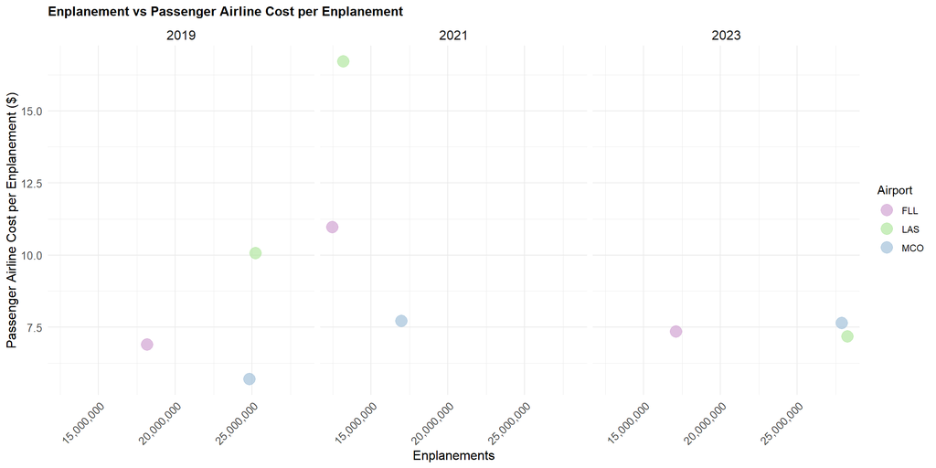

```r
ggplot(airports, aes(x = Enplanements, y = `Passenger.airline.cost.per.enplanement`, color = LOC_ID)) +
  geom_point(alpha = 0.7, size = 5) +
  facet_wrap(~year) +
  scale_x_continuous(labels = label_comma()) +
  scale_color_manual(values = airport_colors) +
  theme_minimal() +
  labs(title = "Enplanement vs Passenger Airline Cost per Enplanement",
       x = "Enplanements",
       y = "Passenger Airline Cost per Enplanement ($)",
       color = "Airport") +
  theme(axis.text.x = element_text(angle = 45, hjust = 1, size = 10),
        axis.text.y = element_text(size = 10),
        axis.title = element_text(size = 12),
        strip.text = element_text(size = 12),
        plot.title = element_text(size = 12, face = "bold"))
```

**Passenger Airline Cost per Enplanement** refers to the total costs incurred by an airport for each enplaned passenger (i.e., each passenger boarding a flight). This financial metric is crucial for evaluating how efficiently an airport handles passengers in relation to its costs. The data reveals an important relationship: when the number of enplanements drops, the Passenger Airline Cost per Enplanement tends to rise.

For FLL, despite enplanements reaching similar levels in 2023 as in 2019, the Passenger Airline Cost per Enplanement remains elevated. This could be due to lower operational efficiency during the recovery phase. On the other hand, LAS has seen a reduction in Passenger Airline Cost per Enplanement post-pandemic, primarily due to higher enplanements and more efficient operations. However, for MCO, even with higher enplanement figures than pre-pandemic, its Passenger Airline Cost per Enplanement has increased. This aligns with MCO’s higher operating expenses, indicating the airport’s increased costs associated with handling passengers.

## References

- Szweda, B. (2024, October 31). The best airports in the US for affordable airfare. AAA Club Alliance. https://cluballiance.aaa.com/the-extra-mile/advice/travel/the-best-airports-in-the-us-for-affordable-airfare
- Statista. (n.d.). Low-cost carrier (LCCs) market in the United States. Statista. Retrieved February 18, 2025, from https://www.statista.com/topics/2849/low-cost-carrier-lccs-market-in-the-united-states/